# BT1101 Practice Exam

25 Nov 2021, 1:00 - 3:30 PM

## Instructions

- **Rename your R Markdown file `FE_[MatricNumber].rmd`**, and the output will automatically be `FE_[MatricNumber].html`.
- Select `output: html_document`.
- Include all code chunks, so include `echo=TRUE` in all chunks.
- Replace the placeholder text, “Type your answer here.”, with your own.
- Preinstall and include any `library('package_name')` statements before exam starts. Remember that there is no Internet connection during the exam.
- Code and type your answer in this Rmarkdown file during exam but **keep in mind that you need to copy and paste all your answer (r-chunk and text) into Essay Answer section for each question in Examplify.**
- Submit your both R Markdown file (.rmd) and HTML (.html) to the folder “Final Exam Submission” in Luminus after Examplify submission and Internet reconnection.
- This Rmarkdown file serves as a reference. **Only answers submitted in Examplify will be graded.** Zero point will be given for blank submission in Examplify even if you have submitted a complete Rmarkdown/HTML file.

## Preparation

```r
# general use
library(dplyr)
library(tidyr)
library(ggplot2)
library(wooldridge)
# descriptive analytics
library(psych)
library(rcompanion)
library (rpivotTable)
library(EnvStats)
library(car)
# predictive/prescriptive analytics
library(tseries)
library(forecast)
library(lpSolve)
# for any randomness
set.seed(1)
# for Monte Carlo simulation, sample size set to be 100, e.g.
n_samples = 100
```

```r
data(saving)
data <-saving
```

1. It is interesting to explain the individual saving sav from various explanatory variables. • Run a linear regression model of sav ~ inc + cons, report the regression output and write out the fitted line. (2 points) • Interpret the intercept as well as the coefficients before inc and cons. (3 points) • Can we use sav, cons and inc altogether as explantory variables in linear regression? Why or why not? (2 points)

```r
lm1 <- lm(sav~inc + cons ,data)

summary(lm1)
```

```
##
## Call:
## lm(formula = sav ~ inc + cons, data = data)
##
## Residuals:
##        Min         1Q     Median         3Q        Max
## -1.998e-11 -4.750e-13 -2.070e-13  4.500e-14  3.642e-11
##
## Coefficients:
##               Estimate Std. Error    t value Pr(>|t|)
## (Intercept)  7.276e-12  8.886e-13  8.188e+00 1.07e-12 ***
## inc          1.000e+00  1.405e-16  7.117e+15  < 2e-16 ***
## cons        -1.000e+00  1.369e-16 -7.303e+15  < 2e-16 ***
## ---
## Signif. codes:  0 '***' 0.001 '**' 0.01 '*' 0.05 '.' 0.1 ' ' 1
##
## Residual standard error: 4.334e-12 on 97 degrees of freedom
## Multiple R-squared:      1,  Adjusted R-squared:      1
## F-statistic: 2.843e+31 on 2 and 97 DF,  p-value: < 2.2e-16
```

sav= 7.28e-12 + inc - cons Intercept: 7.28e-12 If inc and cons are zero in the year, the amount of saving is 7.28e-12 this year

inc : 1.00 If the income increase by 1 dollar, the saving for the year increase by 1 dollar, keeping all other variables constant.

cons : -1.00 If the consumption increase by 1 dollar, the saving for the year decrease by 1 dollar, keeping all other variables constant.

We cannot use them as explanatory variables. Multicollinearity occurs when two or more regressors are highly correlated with each other. In this case, inc - cons = saving. Thus, it is difficult to estimate the errors, which leads to inflated estimates of errors. Also, coefficient for inc and cons are merely definitions of annual income and annual consumption. They are not useful in determining relationships between saving and other regressors.

2. Some labor economists believe that individual consumption is affected not only by income but by his or her education level nonlinearly as well. Let’s first create the following variable educsq which is equal to square of educ. saving wooldridge # load the data set, make sure you already load `wooldridge` package data(saving) saving$educsq = saving$educ^2 • Investigate the relationship between cons and inc visually. Is there a linear relationship between the two? (1 point) • Run and report a linear regression of inc, educ and educsq to explain cons. What’s the marginal effect of education on consumption for those individuals’ education level being 6 year? Interpret this marginal effect. (3 points) Type your answer here

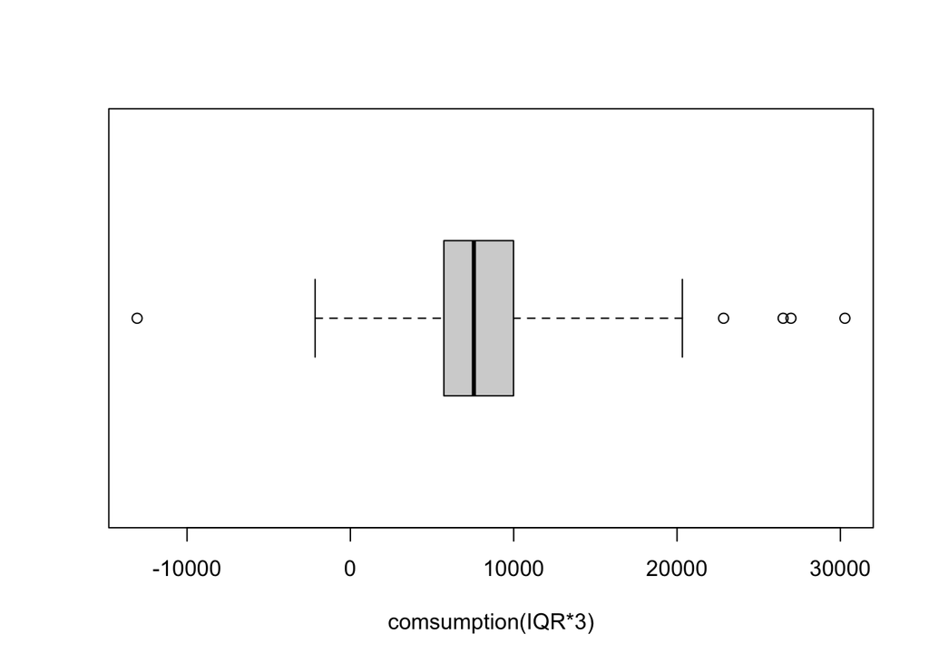

```
## [1]  22848  26975  26495  30280 -13055
```

```r
data$educsq = data$educ^2

#identify outlier
boxplot(data$cons,horizontal = TRUE, range= 3, xlab ="comsumption(IQR*3)") $out
```

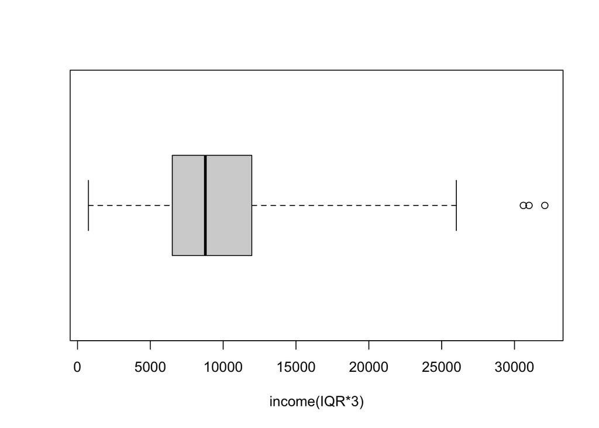

```
## [1] 30996 30610 32080
```

```r
boxplot(data$inc,horizontal = TRUE, range= 3, xlab ="income(IQR*3)") $out
```

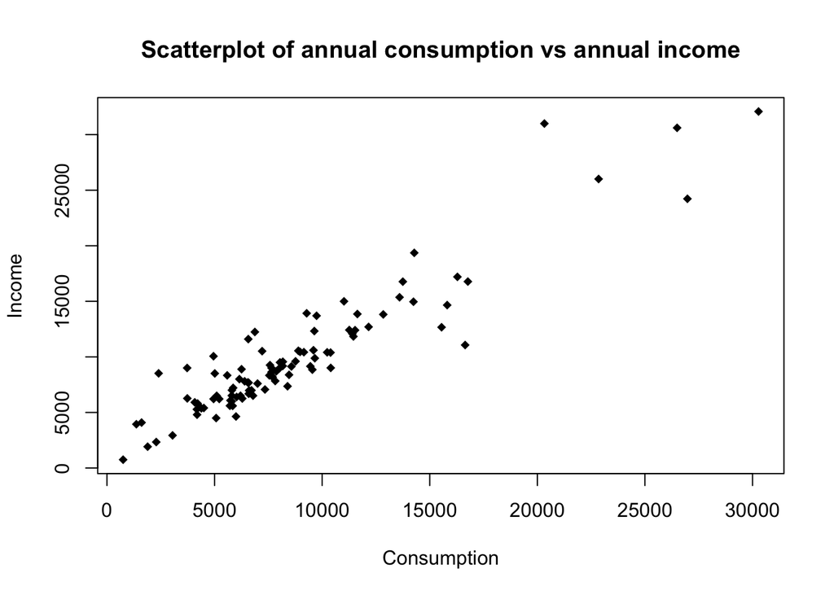

```r
#do not reject and take out these data as it is normal for a household to earn and spend more than other households due to different family size and lifestyle.
#however, take out these values where consumption is negative as it is impossible for consumption to be negative. These values might be recording error.

data_clean <- data %>% filter(cons >0)


plot(data_clean$cons,data_clean$inc, main="Scatterplot of annual consumption vs annual income", xlab="Consumption", ylab="Income", pch=18)
```

```r
#There is a linear relationship between annual consumption and anuual income.

lm2 <- lm(inc~educsq ,data_clean)
lm3 <- lm(inc~educ ,data_clean)


summary(lm2)
```

```
##
## Call:
## lm(formula = inc ~ educsq, data = data_clean)
##
## Residuals:
##    Min     1Q Median     3Q    Max
##  -8169  -3382  -1262   1786  21065
##
## Coefficients:
##             Estimate Std. Error t value Pr(>|t|)
## (Intercept) 5329.144   1044.250   5.103 1.68e-06 ***
## educsq        31.959      6.334   5.045 2.14e-06 ***
## ---
## Signif. codes:  0 '***' 0.001 '**' 0.01 '*' 0.05 '.' 0.1 ' ' 1
##
## Residual standard error: 5035 on 96 degrees of freedom
## Multiple R-squared:  0.2096, Adjusted R-squared:  0.2014
## F-statistic: 25.46 on 1 and 96 DF,  p-value: 2.14e-06
```

```r
summary(lm3)
```

```
##
## Call:
## lm(formula = inc ~ educ, data = data_clean)
##
## Residuals:
##    Min     1Q Median     3Q    Max
##  -7690  -3369  -1179   1622  20695
##
## Coefficients:
##             Estimate Std. Error t value Pr(>|t|)
## (Intercept)   1219.2     1800.1   0.677      0.5
## educ           756.8      150.0   5.045 2.15e-06 ***
## ---
## Signif. codes:  0 '***' 0.001 '**' 0.01 '*' 0.05 '.' 0.1 ' ' 1
##
## Residual standard error: 5035 on 96 degrees of freedom
## Multiple R-squared:  0.2096, Adjusted R-squared:  0.2013
## F-statistic: 25.45 on 1 and 96 DF,  p-value: 2.145e-06
```

3. From the regression output in part (b),
- Is there a nonlinear relationship between education and consumption? Why or why not? (1 points)
- Check the assumptions and discuss what you find. Which assumption(s) are you worry about? (3 points) Type your answer here

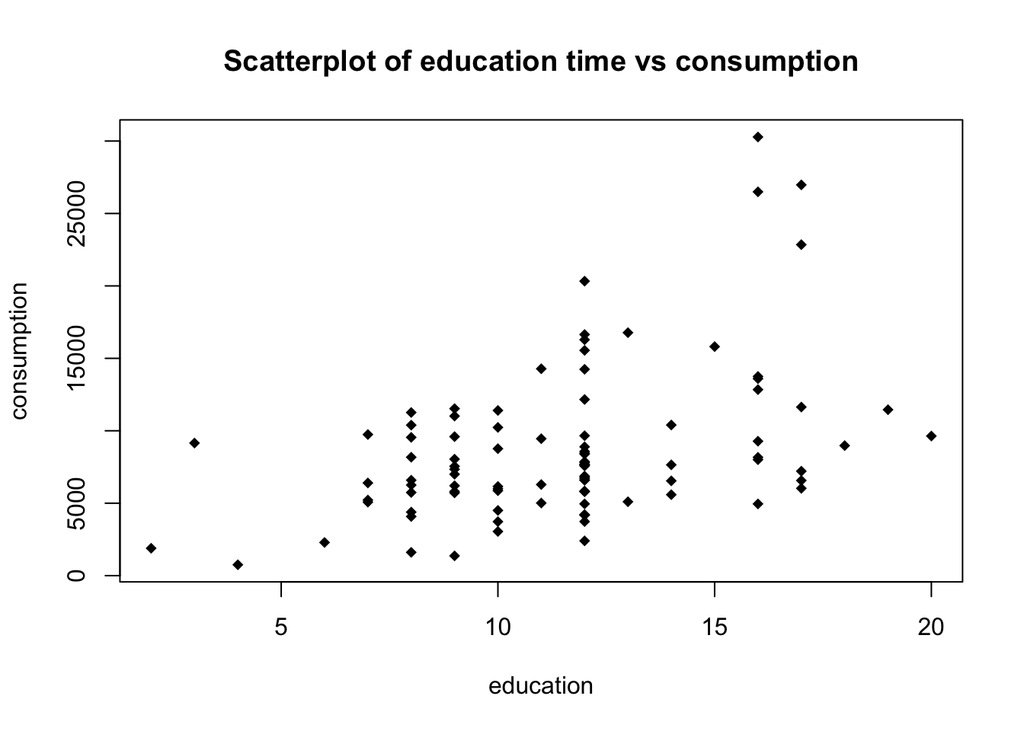

```r
plot(data_clean$educ,data_clean$cons, main="Scatterplot of education time vs consumption", xlab="education", ylab="consumption", pch=18)
```

No, there is a linear relationship between educ and cons as cons and inc are linearly related and educ and inc is linearly related. Hence, cons and educ should be linearly related as well.

Assumption:Linear relationship between DV and IV;No outliers;Normally-distributed errors

Question BT1101-AssemblingPC Prescriptive Analytics (Linear Optimization) Question (total 15 points)

```
 Assume that the FPS performance of the gaming PC is simply sum of delivered FPS of each part. As a first-person shooting gamer, you only care about the performance of frame-per-second (FPS) and requires at least 144 FPS for your new PC. As a student, you obviously would like to spend the least amount of money to assemble a working PC meeting your standard.
```

1. Write down your decision variables, the objective function, and ALL constraints that apply for this optimization problem in a table. You do not need to solve the problem for now. (5 points) Type your answer here

| Minimize total cost using decision variables $X_1$, $X_2$, $X_3$, $X_4$, $X_5$ | return = 499 $X_1$ + 450 $X_2$ + 1099 $X_3$ + 627 $X_4$ + 100 $X_5$ |
| --- | --- |
| Subject to |  |
| fps Constraint | 20 $X_1$ + 18 $X_2$ + 90 $X_3$ + 75 $X_4$ + 10 $X_5$ $\geq$ 144 |
| CPU Constraint | $X_1$ + $X_2$ $=$ 1 |
| GPU Constraint | $X_3$ + $X_4$ $\leq$ 2 |
| RAM Constraint 1 | $X_5$ $\leq$ 4 |
| RAM Constraint 2 | $X_5$ $\geq$ 1 |
| stock constraint 1 | $X_1$ $\leq$ 1 |
| stock constraint 2 | $X_2$ $\leq$ 1 |
| stock constraint 3 | $X_3$ $\leq$ 1 |
| stock constraint 4 | $X_4$ $\leq$ 3 |
| stock constraint 5 | $X_5$ $\leq$ 8 |
| Non-Negativity and Integer Constraint | $X_1$, $X_2$, $X_3$, $X_4$, $X_5$ are all integer and positive |

2. Your trustworthy shop specialist strongly recommended if you choose to get the Nvidia RTX 2080 GPU, your PC needs at least 16GB of RAM. • Write down the constraint in its math expression. (2 points) • As you decide to follow the specialist’s suggestion, solve this problem in R. Which part(s) should you purchase to assemble your gaming PC? How much do you spend on it? (4 points) Type your answer here

```r
objective.fn1 <- c(499,450,1099,627,100)
const.mat1 <- matrix(c(20,18,90,75,10,
                       1,1,0,0,0,
                       0,0,1,1,0,
                       0,0,0,0,1,
                       0,0,0,0,1,
                       1,0,0,0,0,
                       0,1,0,0,0,
                       0,0,1,0,0,
                       0,0,0,1,0,
                       0,0,0,0,1,
                       0,0,1,0,0,
                       0,0,0,0,1),
                     ncol = 5,
                     byrow = TRUE)
const.dir1 <- c(">=","=","<=","<=",">=",rep("<=",5),"=",">=")
const.rhs1 <- c(144,1,2,4,1,1,1,1,3,8,1,2)

lp.solution1 <- lp("min",objective.fn1, const.mat1 , const.dir1, const.rhs1, compute.sens = TRUE,all.int = TRUE)

lp.solution1
```

```
## Success: the objective function is 1949
```

```r
lp.solution1$solution
```

```
## [1] 0 1 1 0 4
```

minimum cost is $1949 , this could be achieved by purchasing one AMD Ryzen ,1 Nvidia RTX 2080 and 4 8G RAM card

3. Now suppose that the price for Nvidia RTX 2080 GPU is uncertain, fluctuating ±55% uniformly based on the current price. You have a budget and thus can pay at most $1500 for your new PC. What’s the prbability that you are not able to get the PC you want at the moment? (4 points) Type your answer here

```r
pnorm(650,1099,1099*0.55,lower.tail = FALSE)
```

```
## [1] 0.7712059
```

price of Nvidia RTX 2080 GPU to satisfy the constraint: 1500-450-100*4 = 650 Find probability that Nvidia RTX 2080 GPU has a price of higher than 650. Assume that price of Nvidia RTX 2080 GPU is normally distributed, which is 0.771.